# Segundo trabalho de Métodos não-paramétricos: dados pareados

## Wesley Furriel - RA:61493

## Prof. Carlos Ap. dos Santos

## **Pacotes utilizados**

library(ggplot2)

library(randtests)

library(dplyr)

library(signmedian.test)

library(exact2x2)

## **Implementação dos testes**

## Teste de aleatorização das iterações

```r
# 1 para +
# 0 para -

iteracao<-function(sinal){
posic<-c(1:length(sinal))
tab<-as.data.frame(cbind(posic,sinal))
tab<-tab%>%mutate(it=cumsum(ifelse(sinal != lag(sinal) | is.na(lag(sinal)),1,0)))
r<-max(tab$it)
n<-tab%>%group_by(sinal)%>%summarize("n"=length(sinal))%>%as.matrix()
  tabF<-qruns(c(0.025,0.975), n[1,2], n[2,2], lower.tail = T)
    if (r>=tabF[1] & r<=tabF[2]){
      print("r de iterações não encontra-se na região de rejeição")
      print(paste(tabF[1],"<","( r =",r,") <",tabF[2],sep=" "))
      }else{ print("r de iterações encontra-se na região de rejeição")
            print(paste(tabF[1],"e",tabF[2],"/"," r =",r,sep=" "))}
}
```

## Teste dos sinais

```r
# lado = 1: Unilateral a direita P(X>k)
# lado = 2: Unilateral a esquerda P(X<k)
# lado = 3: Bilateral

sinalteste<-function(x,mediana,lado){
  med<-mediana
  aux<-c()
  sinal<-ifelse(x<med,aux<-1,aux<-0)
  testesign<-cbind(x,sinal)%>%as.data.frame()
  nsign<-testesign%>%group_by(sinal)%>%summarize("n"=length(sinal))%>%as.matrix()
  m<-length(x)
    if(lado==1){
    sig<-round(pbinom(nsign[1,2],m,0.5),3)}
      if(lado==3){
      sig<-round(2*(1-pbinom(nsign[1,2],m,0.5)),3)}
        if(lado==2){
        sig<-round((1-pbinom(nsign[1,2],m,0.5)),3)}
return(paste("valor.p =",sig,sep=" "))
}
```

## Teste de Wilcoxon

```r
wilcoxon<-function(x,y){
  D <- c(x - y)
  D <- D[D!=0]
  D.rank <-rank(abs(D))
  D.rank.sign <- D.rank*sign(D)
  ranks.posivos <- sum(D.rank.sign[D.rank.sign > 0])
  ranks.negativos <- -sum(D.rank.sign[D.rank.sign < 0])
  tc1<-ranks.posivos
  tc2<-ranks.negativos
    if(length(x)<25){
    n<-length(D.rank)
    Tab.wilcox.li<-c(0,0,0,0,0,0,2,3,5,8,10,13,17,21,25,30,35,40,46,52)
    Tab.wilcox.ls<-c(0,0,0,0,0,21,26,33,40,47,56,65,74,84,95)
    Twli<-Tab.wilcox.li[n];Twls<-Tab.wilcox.ls[n]
    result<-paste("Tc+ =",tc1,"  Tc- =",tc2," | ","Ttab -> ( LI = ",Twli,", LS = ",
    Twls,")",sep="")}
      else{
        n<-length(x)
        mi<-(n*(n+1))/4
        sigma<-sqrt(((n*(n+1))*(2*n+1))/24)
        Zw<-round((tc1-mi)/sigma,3)
        sig<-round(pnorm(Zw,0,1),8)
        result<-paste("Tc+ =",tc1," Tc- =",tc2," | ","Zw =",Zw," e ",
        "sig = ",sig,sep=" ")}
  return(result)
}
```

## **Exercício 9**

Teste dos sinais

$H_0: M_d = 0$ O gasto de energia em repouso é igual

```r
x<-c(1153,1132,1165,1460,1630,1493,1358,1453,1185,1824,1793,1930,2075)
y<-c(996,1080,1182,1452,1162,1619,1140,1123,1113,1463,1632,1614,1836)

#Teste do sinal
d<-x-y;d
```

```
##  [1]  157   52  -17    8  468 -126  218  330   72  361  161  316  239
```

```r
signmedian.test(d,exact = TRUE)
```

```
##
##  Exact sign test
##
## data:  d
## #(x!=0) = 13, mu = 0, p-value = 0.02246
## alternative hypothesis: the median of x is not equal to mu
## 97.75391 percent confidence interval:
##    8 330
## sample estimates:
## point estimator
##             161
```

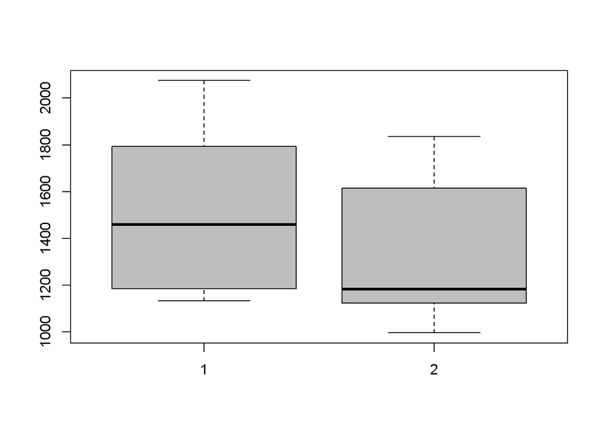

## **Exercício 13**

$H_0: d_{50} = 0$ Os gêmeos tem o mesmo grau de agressividade

$H_1: d_{50} > 0$ O primogênito apresenta maior grau de agressividade

```r
x<-c(89,71,77,68,91,72,77,91,70,71,88,87)
y<-c(88,77,76,64,96,72,65,90,65,80,81,72)

#Teste do sinal
d<-y-x;d
```

```
##  [1]  -1   6  -1  -4   5   0 -12  -1  -5   9  -7 -15
```

```r
signmedian.test(d,alternative = "greater",exact = TRUE)
```

```
##
##  Exact sign test
##
## data:  d
## #(x>0) = 3, mu = 0, p-value = 0.9673
## alternative hypothesis: the median of x is greater than mu
## 93.45703 percent confidence interval:
##  -7  5
## sample estimates:
## point estimator
##              -1
```

```r
#Teste de Wilcoxon
wilcox.test(x,y,paired = T,alternative = "greater")
```

```
##
##  Wilcoxon signed rank test with continuity correction
##
## data:  x and y
## V = 44.5, p-value = 0.1634
## alternative hypothesis: true location shift is greater than 0
```

```r
#Teste de Aleatorização
sinal<-sign(d)
sinal<-ifelse(sign(d)==1,aux<-1,aux<-0)
iteracao(sinal)
```

```
## [1] "r de iterações não encontra-se na região de rejeição"
## [1] "3 < ( r = 7 ) < 7"
```

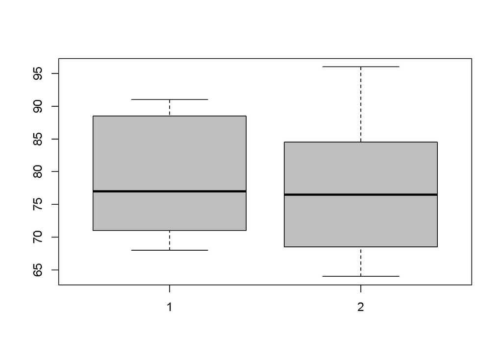

Verificamos que não é possível rejeitamr $H_0$ para qualquer um dos testes empregados,ou seja todos apresentaram o mesmo comportamento, fato que reforça e demonstra que não há evidências de que o primogênito seja mais agressivo.

## **Exercício 14**

Teste Wilcoxon

$H_0: d_{50} = 0$ Não há diferenças entre o estado normal e tenso na pressão sanguínea

$H_1: d_{50} > 0$ A pressão sanguínea é maior quando tenso

Sendo $n<25$

```r
x<-c(126,117,115,118,121,128,125,120)
y<-c(130,118,125,120,118,125,130,120)

wilcoxon(x,y)
```

```
## [1] "Tc+ =7  Tc- =21 | Ttab -> ( LI = 2, LS = 26)"
```

```r
# Conferindo o resultado
wilcox.test(x,y)
```

```
##
##  Wilcoxon rank sum test with continuity correction
##
## data:  x and y
## W = 25, p-value = 0.4907
## alternative hypothesis: true location shift is not equal to 0
```

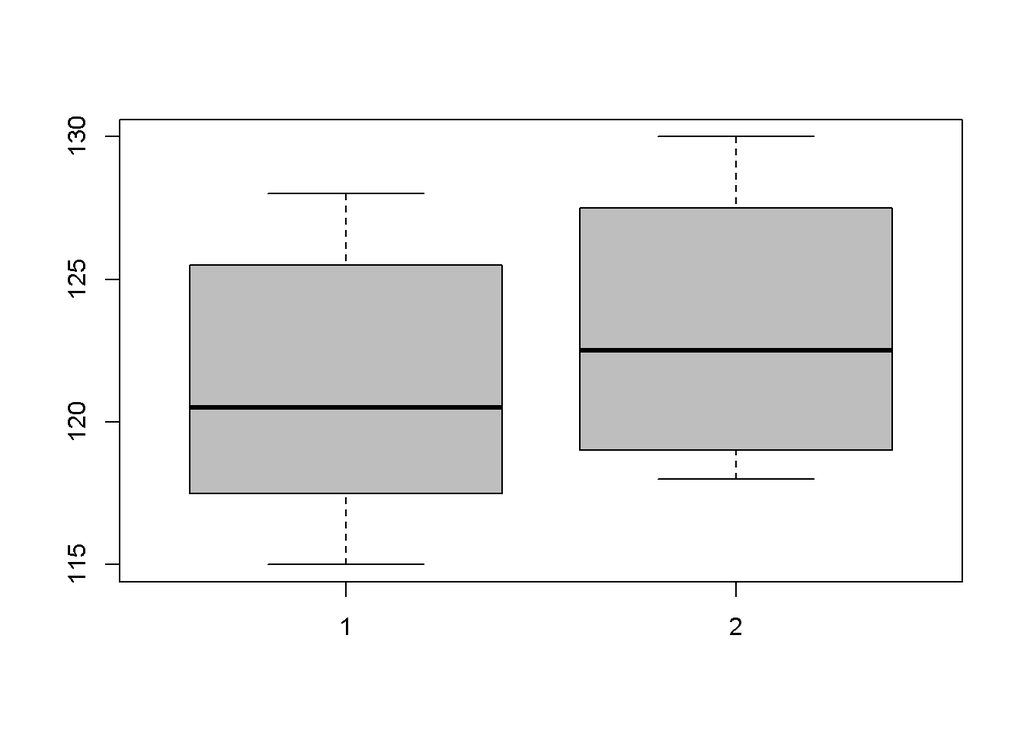

Desse modo não se rejeita $H_0$, ou seja, não há diferenças entre o estado normal e tenso na pressão sanguínea

## **Exercício 15**

Teste Wilcoxon

$H_0: d_{50} = 0$ Não há diferenças entre o peso dos gêmeos

$H_1: d_{50} > 0$ O primeiro a nascer se desenvolve mais

Sendo $n<25$

```r
x<-c(0.72,0.47,0.51,0.59,0.97,0.87,0.36,0.72,0.65,0.48,0.93,0.87,0.81)
y<-c(0.43,0.33,0.49,0.59,0.85,0.80,0.40,0.74,0.62,0.46,0.70,0.78,0.78)

wilcoxon(x,y)
```

```
## [1] "Tc+ =69.5  Tc- =8.5 | Ttab -> ( LI = 13, LS = 65)"
```

```r
# Conferindo o resultado
wilcox.test(x,y,paired = T, alternative = "greater",correct = F)
```

```
##
##  Wilcoxon signed rank test
##
## data:  x and y
## V = 69.5, p-value = 0.008322
## alternative hypothesis: true location shift is greater than 0
```

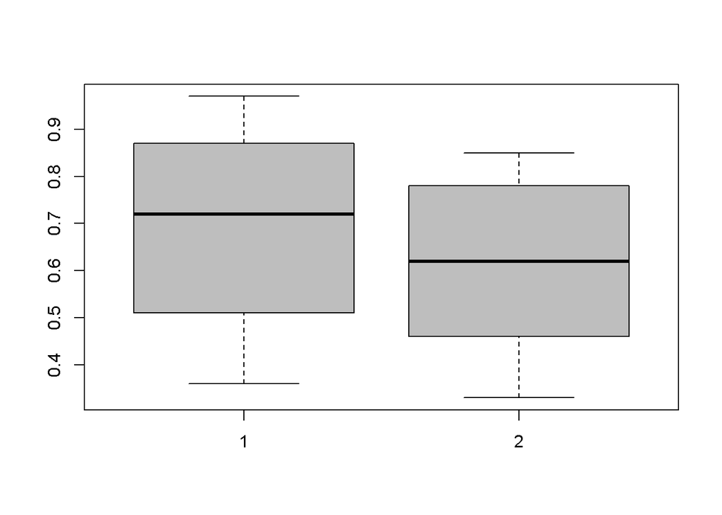

Desse modo se rejeita $H_0$, ou seja, há diferenças entre o peso dos gêmeos, nesse caso o primeiro a nascer se desenvolve mais.

## **Exercício 16**

Teste Wilcoxon

$H_0: d_{50} = 0$ Não há diferenças entre o peso dos gêmeos

$H_1: d_{50} > 0$ Existe diferenças entre o peso dos gêmeos

Sendo $n>25$

```r
x<-c(5.1,4.2,3.3,6,7.1,3.2,2.8,1.4,0.8,5.6,3.8,4.7,6.2,5.4,
     1.2,2.2,1.9,5.4,5.5,5.2,3.8,4.2,1.8,2.6,4.3,1.4)
y<-c(5.8,4.7,6.1,7.4,6.5,3.2,4.5,3.5,4,5.5,3.9,4.5,5,5.4,6,5,
     2.2,1.8,5.2,6,4.5,4.7,5.1,2.9,2.6,6.5)

wilcoxon(x,y)
```

```
## [1] "Tc+ = 67.5  Tc- = 232.5  |  Zw = -2.743  e  sig =  0.00304403"
```

```r
# Conferindo o resultado
wilcox.test(x,y,paired = T)
```

```
##
##  Wilcoxon signed rank test with continuity correction
##
## data:  x and y
## V = 67.5, p-value = 0.01911
## alternative hypothesis: true location shift is not equal to 0
```

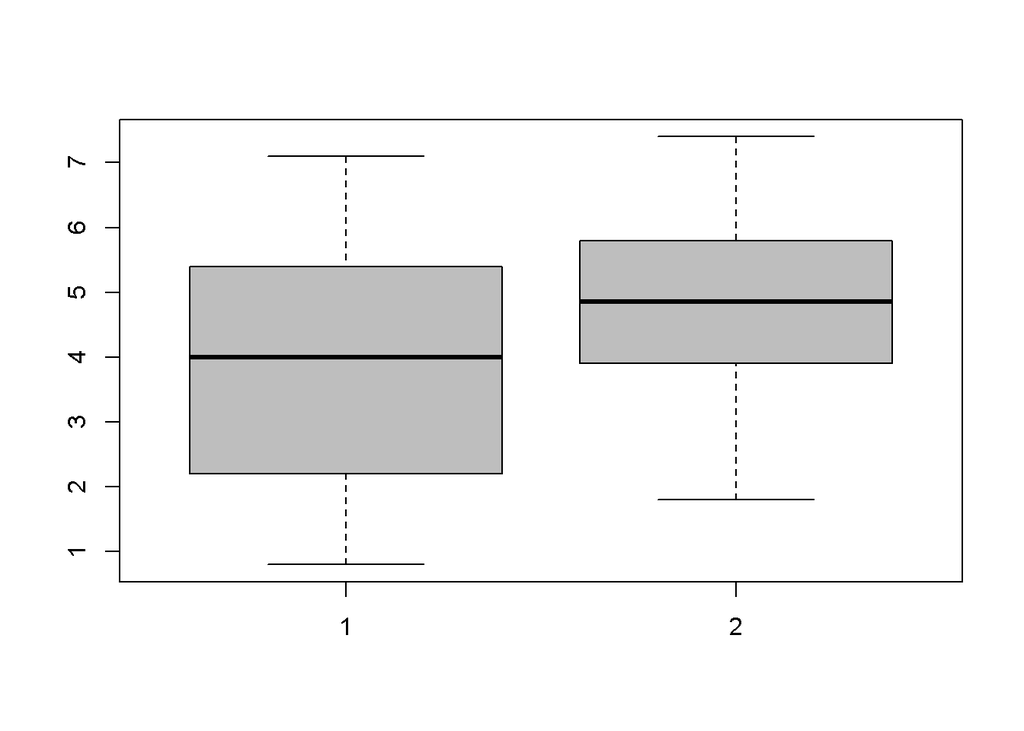

## **Exercício 17**

Teste Wilcoxon

$H_0: d_{50} = 0$ Não ocorreram melhoras

$H_1: d_{50} < 0$ Ocorreram melhoras

Sendo $n<25$

```r
x<-c(6,1,14,2,23,18,14,9,14,2,3,17,6)
y<-c(7,1,20,2,9,13,2,4,14,4,4,15,5)

wilcoxon(x,y)
```

```
## [1] "Tc+ =38.5  Tc- =16.5 | Ttab -> ( LI = 8, LS = 47)"
```

```r
# Conferindo o resultado
wilcox.test(x,y,paired = T)
```

```
##
##  Wilcoxon signed rank test with continuity correction
##
## data:  x and y
## V = 38.5, p-value = 0.2826
## alternative hypothesis: true location shift is not equal to 0
```

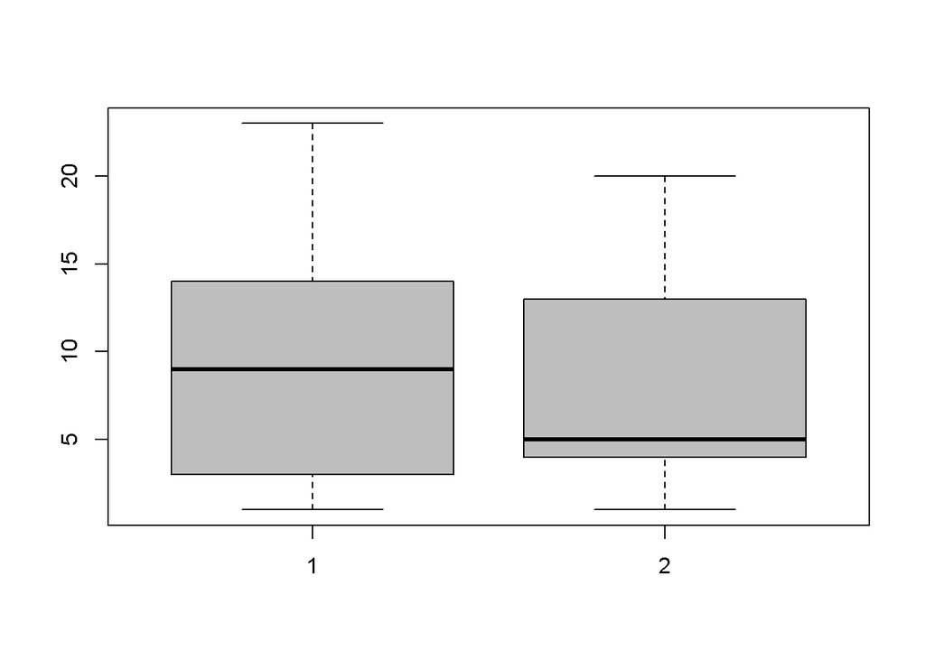

Dessa forma, não é possível rejeitar $H_0$, ou seja, não ocorreram melhoras nos escores de depressão.